# Supermarket Sales

Gloria  
September 8, 2020

### Myanmar Supermarket Sales

There are many factors that must be taken into account when looking at consumer logistics and determining a businesses revenue from it. Such factors are including but not limited to:

- location of purchase
- product category
- membership to store
- product unit price
- number of items bought
- payment method
- customer rating
- customer gender

### A little about the Dashboard

Here, supermarket sales were retrieved from [kaggle](https://www.kaggle.com/aungpyaeap/supermarket-sales) and used to create a shiny dashboard to observe how these factors influence revenue trends in the a 3 month period (January to March 2019). This is all in the second tab.

Predictive modeling is used in the third tab to predict total spending at a supermarket by a customer based on the previously mentioned factors. With every update of the different drop boxes and sliders, prediction is updated in the back-end and resulting in an update predicted value in the dashboard.

### Glimpse into Dashboard Tab

[figure not shown]

```r
library(leaflet)

myanmar_df=data.frame(City=c('Mandalay', 'Naypyitaw', 'Yangon'),
                          lat=c(21.9588, 19.7633, 16.8409),
                          lng=c(96.0891, 96.0785, 96.1735))

myanmar_df %>% leaflet() %>% addTiles() %>% addMarkers(label=~City)
```

### Predictor Tab

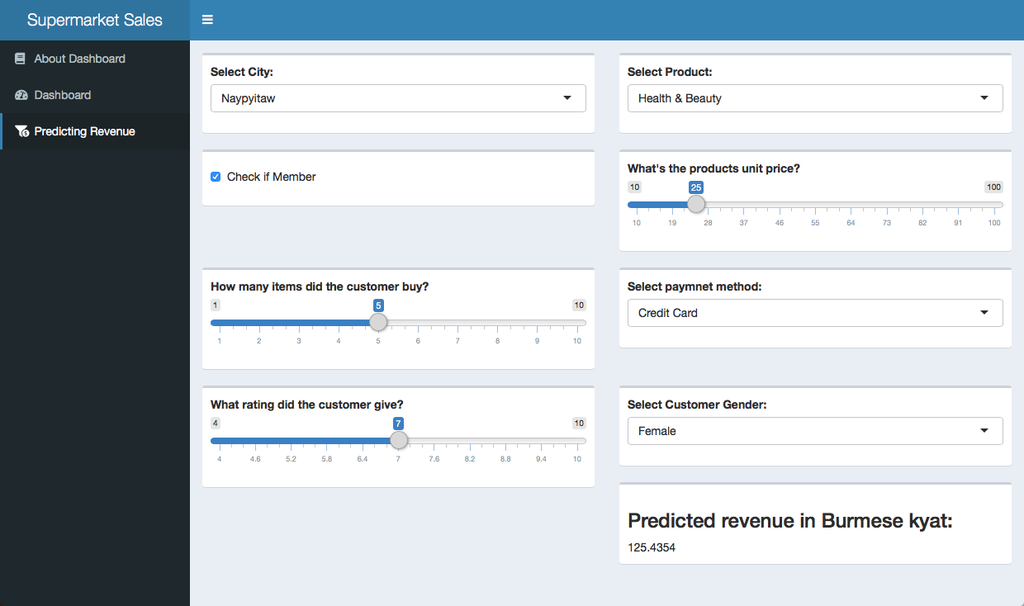

This is a screen shot of the prediction revenue tab of the [dashboard](https://gdq12.shinyapps.io/shiny_dashboard/). **To take a look at the dashboard, best to open in a simple web browser like safari (issues with rendering graphs due to perhaps java script).** If you want to have a look at the app.R (ui and server.R combo) file used to generate the dash board, have a look in [github](https://github.com/gdq12/Shiny_Dashboard/blob/master/app.R).